# Reproducible Research: Peer Assessment 1

## Loading and preprocessing the data

First, we are loading the activity.csv file into a data frame.

```r
activity <- read.csv("activity.csv")
```

Let’s take a look at the data frame’s structure and how the data might look like:

```r
str(activity)
```

```
## 'data.frame':    17568 obs. of  3 variables:
##  $ steps   : int  NA NA NA NA NA NA NA NA NA NA ...
##  $ date    : Factor w/ 61 levels "2012-10-01","2012-10-02",..: 1 1 1 1 1 1 1 1 1 1 ...
##  $ interval: int  0 5 10 15 20 25 30 35 40 45 ...
```

Since `date` is currently regarded as a factor we change its type to `Date`:

```r
activity$date <- as.Date(activity$date, format="%Y-%m-%d")
```

Now, we the date is structured like this:

```r
str(activity)
```

```
## 'data.frame':    17568 obs. of  3 variables:
##  $ steps   : int  NA NA NA NA NA NA NA NA NA NA ...
##  $ date    : Date, format: "2012-10-01" "2012-10-01" ...
##  $ interval: int  0 5 10 15 20 25 30 35 40 45 ...
```

## What is mean total number of steps taken per day?

In order to calculate the mean and median values we first calculate the total number of steps taken each day.

```r
totalStepsPerDay <- aggregate(steps ~ date, data = activity, FUN = "sum")
```

The data looks something like this:

```r
head(totalStepsPerDay)
```

```
##         date steps
## 1 2012-10-02   126
## 2 2012-10-03 11352
## 3 2012-10-04 12116
## 4 2012-10-05 13294
## 5 2012-10-06 15420
## 6 2012-10-07 11015
```

Thereafter, mean and median values can easily be derived.

```r
totalStepsPerDay_mean <- mean(totalStepsPerDay$steps)
totalStepsPerDay_median <- median(totalStepsPerDay$steps)
```

Mean (10766 total steps per day) and median (10765 total steps per day) values lie rather close together.

In order to get mean and median values, the `summary()` function could also be helpful.

```r
summary(totalStepsPerDay)
```

```
##       date                steps
##  Min.   :2012-10-02   Min.   :   41
##  1st Qu.:2012-10-16   1st Qu.: 8841
##  Median :2012-10-29   Median :10765
##  Mean   :2012-10-30   Mean   :10766
##  3rd Qu.:2012-11-16   3rd Qu.:13294
##  Max.   :2012-11-29   Max.   :21194
```

## What is the average daily activity pattern?

In order to plot a line graph of the average number of steps taken (averaged accross all days) in each 5-minute interval, we first aggregate the activity data once more. This time, we calculate the average number of steps per interval:

```r
avgStepsPerInterval <- aggregate(steps ~ interval, data = activity, FUN = "mean")

# just to show the avg. number of steps across all intervals in the graph as well
avgStepsAcrossIntervals <- mean(avgStepsPerInterval$steps)
```

Next, the dataset-index with the maximum number of steps and the corresponding interval can be calculated by:

```r
maxIndex <- which.max(avgStepsPerInterval$steps)
avgStepsPerInterval$steps[maxIndex]
```

```
## [1] 206.2
```

```r
avgStepsPerInterval$interval[maxIndex]
```

```
## [1] 835
```

Thus, we can state that across all the days in the dataset interval 835 contains the maximum number of steps. Namely 206.2.

Finally, a corresponding plot might be generated like this (using `ggplot2`):

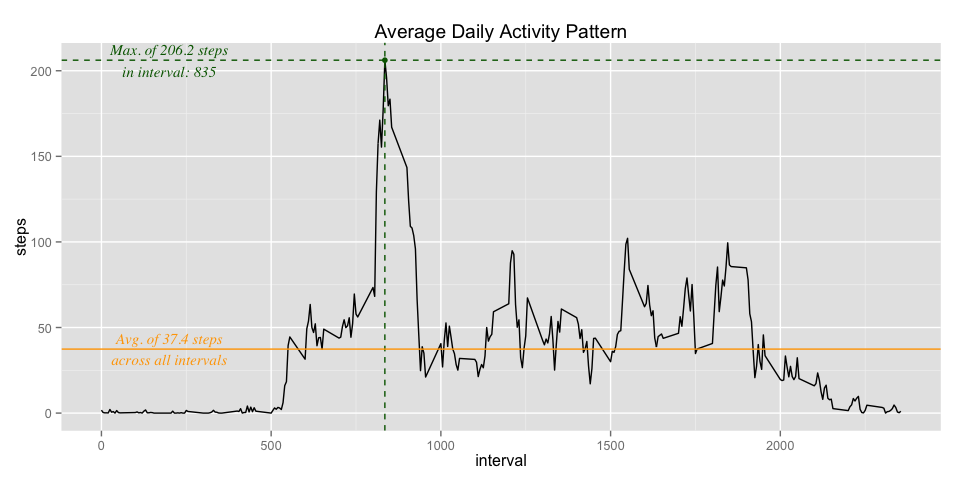

```r
library(ggplot2)

ggplot(data = avgStepsPerInterval, aes(x = interval, y = steps)) +
    geom_line() +
    geom_point(data = avgStepsPerInterval[maxIndex, ],
               aes(x = interval, y = steps), col = "darkgreen") +
    geom_vline(aes(xintercept=avgStepsPerInterval$interval[maxIndex]),
               col = "darkgreen", linetype="dashed") +
    geom_hline(aes(yintercept=avgStepsPerInterval$steps[maxIndex]),
               col = "darkgreen", linetype="dashed") +
    annotate("text", x = 200, y = avgStepsPerInterval$steps[maxIndex],
             label=sprintf("Max. of %.1f steps\nin interval: %.0f",
                           avgStepsPerInterval$steps[maxIndex],
                           avgStepsPerInterval$interval[maxIndex]),
             family = "serif", fontface = "italic", col = "darkgreen", size = 4) +
    geom_hline(aes(yintercept=avgStepsAcrossIntervals), col = "orange") +
    annotate("text", x = 200, y = avgStepsAcrossIntervals,
             label=sprintf("Avg. of %.1f steps\nacross all intervals",
                           avgStepsAcrossIntervals),
             family = "serif", fontface = "italic", col = "orange", size = 4) +
    ggtitle("Average Daily Activity Pattern")
```

## Imputing missing values

First, let’s get an idea which and how many values are missing. Neither `date` nor `interval` column do have `NA` values:

```r
sum(is.na(activity$date))
```

```
## [1] 0
```

```r
sum(is.na(activity$interval))
```

```
## [1] 0
```

Apparently, some `steps` are missing:

```r
totalNumberOfNAs <- sum(is.na(activity$steps))
totalNumberOfObservations <- length(activity$steps)
missingPercentage  <- totalNumberOfNAs/totalNumberOfObservations * 100
```

2304 out of 17568 values in the given activity dataset are missing which is a percentage of 13.1%.

Secondly, we need a strategy for filling missing step values (`NA`): I have decided to fill in the mean value of steps for that particular 5-minute interval. This allows me to reuse the `avgStepsPerInterval` data frame:

```r
tempDf <- merge(x = activity,
                y = avgStepsPerInterval,
                by = "interval",
                all.x = TRUE)

# fill NAs with mean of appropriate interval
tempDf[is.na(tempDf$steps.x),"steps.x"] <- tempDf[is.na(tempDf$steps.x),"steps.y"]

# and rename steps.x to steps
names(tempDf)[names(tempDf) == "steps.x"] <- "steps"

# finally create dataset equal to the original one but without NAs
activityWithoutNAs <- tempDf[order(tempDf$date, tempDf$interval), c("steps", "date", "interval")]
```

This gives us a dataset that is equal to the original dataset…

```r
str(activityWithoutNAs)
```

```
## 'data.frame':    17568 obs. of  3 variables:
##  $ steps   : num  1.717 0.3396 0.1321 0.1509 0.0755 ...
##  $ date    : Date, format: "2012-10-01" "2012-10-01" ...
##  $ interval: int  0 5 10 15 20 25 30 35 40 45 ...
```

…but without missing data

```r
sum(is.na(activityWithoutNAs$steps))
```

```
## [1] 0
```

Let’s prepare the data for a histogram showing the total number of steps taken each day. Since I would like to show the differences between the datasets with and without missing values, I create a combined data frame.

```r
withNAs <- activity
withNAs$origDataset <- "with NAs"
withoutNAs <- activityWithoutNAs
withoutNAs$origDataset <- "without NAs"

activities <- rbind(withNAs, withoutNAs)

# calculate total number of steps per date based on original dataset (either with or without missing values).
activitiesPerDay <- aggregate(steps ~ origDataset + date,
                              data = activities, FUN = "sum", na.rm = FALSE)
```

With the `activitiesPerDay` dataset, a histogramm can be drawn that shows the differences between data with and without `NAs` side by side.

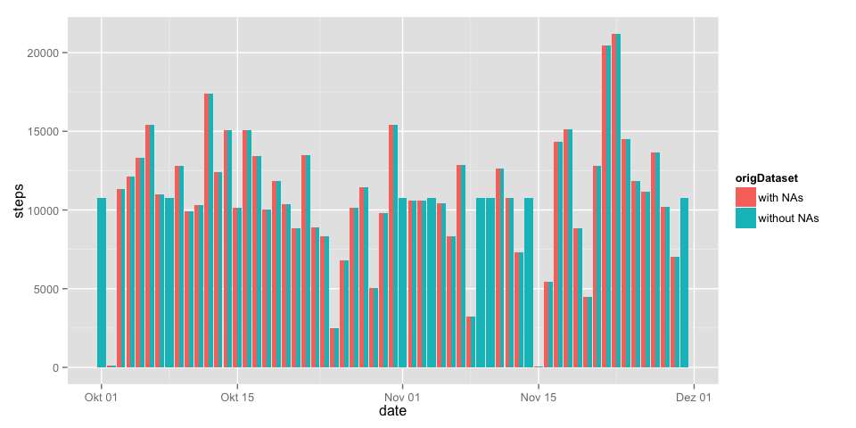

```r
ggplot(data = activitiesPerDay, aes(x=date, y=steps, fill=origDataset)) +
    geom_bar(stat = "identity", position = "dodge")
```

We can identify a couple of bars where apparently only values from the dataset without missing values do exist. Since all of them seem to have the same y-value, I would assume that on those days the original dataset does not contain even a single measurement. Let’s have a look: On which dates do we have missing values?

```r
onlyNAs <- activity[is.na(activity$steps),]
datesWithNAs <- unique(onlyNAs$date)
datesWithNAs
```

```
## [1] "2012-10-01" "2012-10-08" "2012-11-01" "2012-11-04" "2012-11-09"
## [6] "2012-11-10" "2012-11-14" "2012-11-30"
```

Only for these 8 dates, missing values exist. Nevertheless, let’s see if there have been (at least some) correct measurements on these days.

```r
presentAndMissingValuesAtSameDate <- activity[activity$date %in% datesWithNAs && !is.na(activity$steps), ]
presentAndMissingValuesAtSameDate
```

```
## [1] steps    date     interval
## <0 rows> (or 0-length row.names)
```

No. That is, we have 8 days for which step-measurements miss entirely. This explains why all bars from the dataset without missing values have the same height in the histogramm above. We have filled this dataset with the same average values for the particular intervals.

This should also be noticable when we look at the mean values for the total number of steps taken per day for both datasets. There should be no change by inputing these missing values:

```r
aggregate(steps ~ origDataset, data = activitiesPerDay,
          FUN = "mean")
```

```
##   origDataset steps
## 1    with NAs 10766
## 2 without NAs 10766
```

The median however may change a bit:

```r
aggregate(steps ~ origDataset, data = activitiesPerDay,
          FUN = "median")
```

```
##   origDataset steps
## 1    with NAs 10765
## 2 without NAs 10766
```

## Are there differences in activity patterns between weekdays and weekends?

To answer this question, we will first create a new dataset (based on the activity-dataset without missing values) that contains a new column `day` which holds one of the two factor values `weekday` or `weekend`.

```r
activitiesOnDays <- activityWithoutNAs

# create logical vectors for saturdays and sundays
sundays <- format(activitiesOnDays$date, "%w") == 0
saturdays <- format(activitiesOnDays$date, "%w") == 6

# add new day-column and fill it with string weekend or weekday, respectively.
activitiesOnDays$day <- ifelse(sundays, "weekend", ifelse(saturdays, "weekend", "weekday"))

# make day a factor-column
activitiesOnDays$day <- as.factor(activitiesOnDays$day)
```

Calculate the mean value of steps per weekday/weekend and interval, which we need for the following line graph.

```r
avgStepsPerIntervalAndDay <- aggregate(steps ~ day + interval, data = activitiesOnDays, FUN = "mean")
```

And here is the plot, comparing average number of steps taken, averaged across all weekday days or weekend days:

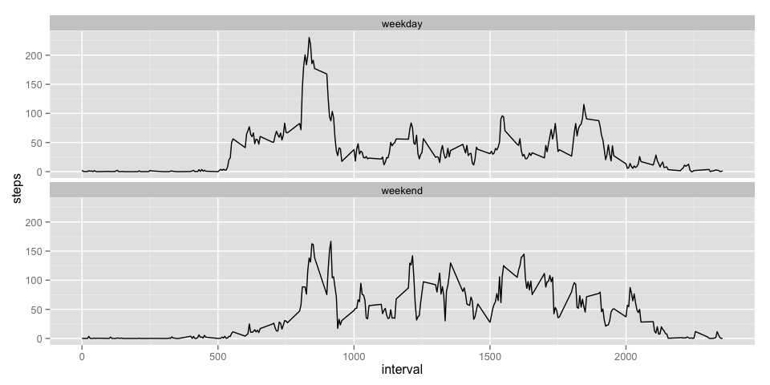

```r
ggplot(data = avgStepsPerIntervalAndDay, aes(x = interval, y = steps)) +
    geom_line() + facet_wrap(~ day, ncol = 1)
```

As can be seen from the graph, the activity tends to start later on a weekend day and does not reach the maximum of a weekday day. However, on average more steps in total are taken on a weekend day on average:

```r
avgTotalStepsPerWeekday <- sum(avgStepsPerIntervalAndDay[avgStepsPerIntervalAndDay$day == "weekday", ]$steps)

avgTotalStepsPerWeekend <- sum(avgStepsPerIntervalAndDay[avgStepsPerIntervalAndDay$day == "weekend", ]$steps)

avgTotalStepsPerWeekday
```

```
## [1] 10256
```

```r
avgTotalStepsPerWeekend
```

```
## [1] 12202
```